# Supervised learning: Classification 1

## Visualising the effect of the balance variable

In two steps, we will visualise the effect `balance` has on the predicted default probability.

12. **Create a data frame called `balance_df` with 3 columns and 500 rows: `student` always 0, `balance` ranging from 0 to 3000, and `income` always the mean income in the `default_train` dataset.**

```r
balance_df <- tibble(
  student = rep(0, 500),
  balance = seq(0, 3000, length.out = 500),
  income  = rep(mean(default_train$income), 500)
)
```

13. **Use this dataset as the `newdata` in a `predict()` call using `lr_mod` to output the predicted probabilities for different values of `balance`. Then create a plot with the `balance_df$balance` variable mapped to x and the predicted probabilities mapped to y. Is this in line with what you expect?**

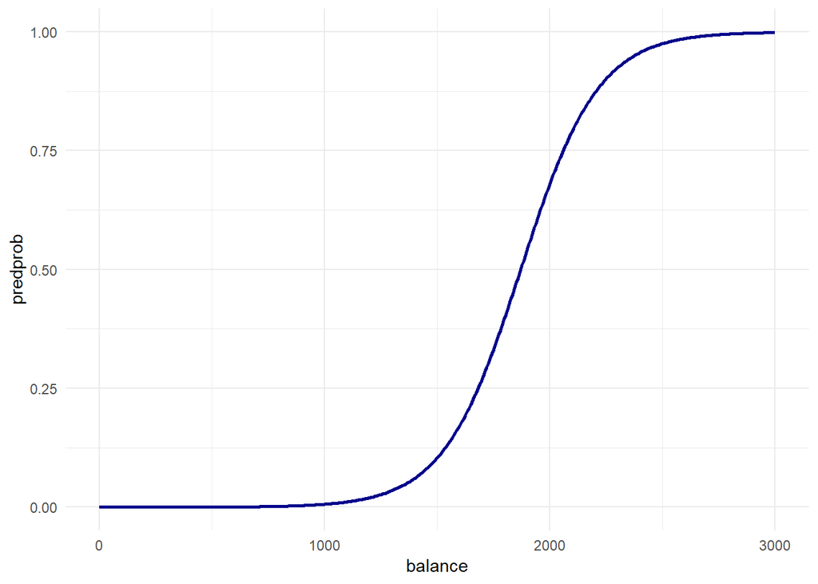

```r
balance_df$predprob <- predict(lr_mod, newdata = balance_df, type = "response")

balance_df %>%
  ggplot(aes(x = balance, y = predprob)) +
  geom_line(col = "dark blue", size = 1) +
  theme_minimal()
```

```r
# Just before 2000 in the first plot is where the ratio of
# defaults to non-defaults is 50-50. So this line is exactly what we expect!
```

14. **Create a confusion matrix just as the one for the KNN models by using a cutoff predicted probability of 0.5. Does logistic regression perform better?**

```r
pred_prob <- predict(lr_mod, newdata = default_test, type = "response")
pred_lr   <- factor(pred_prob > .5, labels = c("No", "Yes"))

table(true = default_test$default, predicted = pred_lr)
```

```
##      predicted
## true    No  Yes
##   No  1918   11
##   Yes   48   23
```

```r
# logistic regression performs better in every way than knn. This depends on
# your random split so your mileage may vary
```

# Linear discriminant analysis

The last method we will use is LDA, using the `lda()` function from the `MASS` package.

15. **Train an LDA classifier `lda_mod` on the training set.**

```r
lda_mod <- lda(default ~ ., data = default_train)
```

16. **Look at the `lda_mod` object. What can you conclude about the characteristics of the people who default on their loans?**

```r
lda_mod
```

```
## Call:
## lda(default ~ ., data = default_train)
##
## Prior probabilities of groups:
##      No     Yes
## 0.96725 0.03275
##
## Group means:
##       student   balance   income
## No  0.2924528  801.3853 33518.72
## Yes 0.4007634 1745.9680 31448.21
##
## Coefficients of linear discriminants:
##                   LD1
## student -1.514522e-01
## balance  2.255909e-03
## income   3.244933e-06
```

```r
# defaulters have a larger proportion of students that non-defaulters
# (40% vs 29%), they have a slightly lower income, and they have a
# much higher remaining credit card balance than non-defaulters.
```

17. **Create a confusion matrix and compare it to the previous methods.**

```r
pred_lda <- predict(lda_mod, newdata = default_test)
table(true = default_test$default, predicted = pred_lda$class)
```

```
##      predicted
## true    No  Yes
##   No  1922    7
##   Yes   53   18
```

```r
# It has slightly more false negatives, a lower false positive rate,
# and fewer true positives than logistic regression.
```

# Final assignment

18. **Create a model (using knn, logistic regression, or LDA) to predict whether a 14 year old boy from the 3rd class would have survived the Titanic disaster. You can find the data in the `data/` folder. Would the passenger have survived if they were a girl in 2nd class?**

```r
titanic <- read_csv("data/Titanic.csv")
# I'll do a logistic regression with all interactions
lr_mod_titanic <- glm(Survived ~ PClass * Sex * Age, data = titanic)

predict(lr_mod_titanic,
        newdata = tibble(
          PClass = c( "3rd",    "2nd"),
          Age    = c(    14,       14),
          Sex    = c("male", "female")
        ),
        type = "response"
)
```

```
##         1         2
## 0.2215689 0.9230483
```

```r
# So our hypothetical passenger does not have a large survival probability:
# our model would classify the boy as not surviving. The girl would likely
# survive however. This is due to the women and children getting preferred
# access to the lifeboats. Also 3rd class was way below deck.
```